# Replicating ["The Structure of Economic News"](https://www.nber.org/papers/w26648) (Bybee et al. 2021)

```python
## from BKMX paper
subject_labels = pd.read_csv('../filters/djn_subject_labels.csv',
                                 header=None)[1].to_list()

subject_labels
```

```
['description',
 'Biography',
 'Basketball',
 'Baseball',
 'Colleges & Universities',
 'Farnborough Air Show',
 'Fashion',
 'Football',
 'Golf',
 'Getting Personal',
 'Hockey',
 'Letters to the Editor',
 'Lifestyles',
 'Obituaries',
 'Religion',
 'Soccer',
 'Sports',
 'Sports & Recreation',
 'Tabular Material',
 'Test Message',
 'Tennis',
 'Travel']
```

```python
## subject filter first time

subject_list = ['Sports',
                'Sport',
                'Game',
                'Olympics',
                'Olympic',
                'Leisure',
                'Weekends',
                'Yacht',
                'Mansion',
                'Resorts & spas',
                'Cooking',
               'Food',
                'Wine',
               'Travel',
               'Book',
                'Books',
                'Literature',
                'Love',
                'Fiction',
                'Writer',
                'Novel',
                'Arts',
                'Art',
                'Musuem',
                'Restaurant',
                'Film',
                'Opera',
                'Theater',
                'Music',
                'TV',
               'Obituary',
               'Poetry',
               'Culture',
                'Religion',
                'Dance',
                'Exhibition',
                'Culture commentary',
               'Book reviews',
               'Basketball',
               'Boxing',
               'NBA',
               'Fashion',
               'Poetry',
                'Philosophy',
               'NFL',
               'Tennis',
                'Soccer',
               'Style',
               'Marriage',
               'Abortion',
               'Phisics',
               'Psychology',
               'History',
               'Justice',
               'Police',
               'FIFA',
               'Crime',
               'Laws',
               'Constitution',
               'Court',
               'Supreme court',
               'Shooting',
               'Guns',
                'Gun',
               'Race',
               'Gender',
               'Children',
               'Education']

subject_list = subject_list + subject_labels

for subject in subject_list:
    article_data = exclude_subjects(subject,
                                    article_data)
```

```python
len(article_data)
```

```
2374
```

```python
## headline patterns filter

headlines_patterns = pd.read_csv('../filters/regex_drop_headlines.csv',
                                 header=None)[0].to_list()

for pattern in headlines_patterns:
    print(pattern)
    article_data = exclude_headlines(pattern,
                                    article_data)
```

[output not shown]

[output cut: 207 more lines]

```
tv -
u\.s\. market to close
watching the web
weekend invest
weekend journal
weekend report
what's news:
what's news -
what's your workout
who's news
wine:
wine -
winter olym
work & family
workspaces
```

```python
len(article_data)
```

```
2187
```

```python
## export subject tags to txt file

with open(res_path+'/subjects_list.txt','w') as f:
    for subjects in list(article_data['subjects'].unique()):
        for subject in subjects.split(','):
            f.write(subject+'\n')
```

```python
## after filtering
article_data.sample(n=30)
```

|  | Article ID | text | date | subjects | title | day_of_week | length |
| --- | --- | --- | --- | --- | --- | --- | --- |
| 1719 | 398169187.xml | NEW YORK -- Most interest rates rose sli... | 1988-09-23 | Refinancing,Treasuries,Economic conditions,Col... | Most Interest Rates Rise in Dull Trading After... | 4 | 11285 |
| 2221 | 398786784.xml | Will Amazon.com Inc. delight Wall Stre... | 2001-12-03 | Electronic commerce,Corporate profits,Sales fo... | Amazon.com's Meter Delights, Perhaps Overly | 0 | 6198 |
| 966 | 398175108.xml | STILLWATER, Minn. -- Incstar Corp. said ... | 1989-01-12 | Retirement of debt,Medical tests, | Incstar Cuts Estimate For Fiscal '89 Earnings | 3 | 1238 |
| 2214 | 398011633.xml | NEW YORK -- Donald J. Trump and Intersta... | 1987-09-29 | Interest rates,Developers,Alliances, | Trump and Interstate Properties End Talks To B... | 1 | 2238 |
| 13 | 399118270.xml | Taiwan authorities imprisoned former Pre... | 2008-11-12 | Money laundering,Arrests,Corruption in governm... | World News: Taiwan's Ex-President Is Imprisoned | 2 | 1920 |
| 2941 | 1646549238.xml | Efforts to inject new life into Staten ... | 2015-01-20 | Office space,Economic development,Tax incremen... | Commercial Property: Push for Development at T... | 1 | 4407 |
| 1549 | 398593239.xml | Travelers Group Inc., New York, which ... | 1995-08-28 | Stockholders,Divestiture,Insurance industry,Lo... | Travelers Group Inc.: Transport's 1.6 million ... | 0 | 598 |
| 2106 | 398859127.xml | DALLAS -- Pegasus Systems Inc.'s board... | 1999-12-09 | Stock splits, | Pegasus Systems to Split Stock | 3 | 341 |
| 1875 | 1346106893.xml | New York City mayoral candidate John Li... | 2013-04-26 | Political campaigns,Political finance,Trials,F... | Liu Stands By His Aide | 4 | 5231 |
| 1450 | 398788338.xml | Roadway Corp. said fiscal third-quarte... | 2002-09-25 | Earnings per share,Financial performance,Compa... | Business Brief -- Roadway Corp.: Fiscal 3rd-Pe... | 2 | 858 |
| 2203 | 398708822.xml | Boeing Co. is near an agreement under ... | 2000-07-05 | Aircraft,Purchase orders,Leasing,Airlines, | Boeing Is Close to Deal to Sell 30 Planes To L... | 2 | 3639 |
| 2615 | 398564031.xml | BEIJING -- China's industrial output ... | 1994-12-12 | Industrial production, | China's Industrial Output Up | 0 | 335 |
| 799 | 398773100.xml | A U.S. federal judge has decided that ... | 2000-08-30 | Medicaid,Agreements,Health care access,Emergen... | Judge Says Texas Broke Agreement on Medicaid | 2 | 5162 |
| 2184 | 398276050.xml | RJR NABISCO HOLDINGS Corp.(New York) ... | 1992-05-18 | Research & development--R&D,Alliances, | RJR Nabisco Holdings Corp. | 0 | 499 |
| 815 | 1020944648.xml | ALBANY -- Gov. Andrew Cuomo warned teach... | 2012-06-19 | Standardized tests,Teachers,Teacher evaluation... | Teacher Rankings, Marijuana Unresolved | 1 | 4730 |
| 373 | 398606645.xml | Brad Grey, the TV producer and persona... | 1995-08-18 | Television directors & producers,Appointments ... | TV producer Grey is being wooed by Disney, MCA | 4 | 3027 |
| 640 | 398245649.xml | RESTON, Va. -- US Sprint Communicatio... | 1990-04-04 | Service introduction, | US Sprint Launches a Service | 2 | 391 |
| 898 | 398379518.xml | DEARBORN, Mich. -- CMS Energy Corp. s... | 1993-11-17 | Petroleum industry,Acquisitions & mergers, | CMS Energy's Nomeco Oil unit | 2 | 479 |
| 1763 | 398009935.xml | Mobil Corp. reported that second-quarter... | 1987-07-29 | Marketing,Profit margins,Sales,Corporate profi... | Mobil Earnings Declined 48% In 2nd Quarter ---... | 2 | 5553 |
| 676 | 398128698.xml | Enterprise Oil PLC, a British independen... | 1988-07-25 |  | International Corporate Report: Enterprise Oil... | 0 | 615 |
| 387 | 397963385.xml | A strengthening U.S. dollar pummeled for... | 1984-11-27 | Prime rate,Discount rates,Currency,Interest ra... | Dollar Jumps Despite Drop In Prime Rate --- De... | 1 | 4424 |
| 1781 | 398213232.xml | In 1980, economist Julian Simon bet E... | 1990-12-14 | School districts, | REVIEW &amp; OUTLOOK (Editorial) -- Asides: Si... | 4 | 1069 |
| 2841 | 398261991.xml | NEW YORK -- Moody's Investors Service... | 1991-12-03 | Automobile industry,Bond ratings,Market positi... | Arvin's Debt Ratings Lowered by Moody's | 1 | 1570 |
| 1578 | 398596562.xml | Imo Industries Inc., Lawrenceville, N.J.... | 1995-11-21 | Alliances,Joint ventures, | Business Brief -- IMO INDUSTRIES INC.: Roltra-... | 1 | 561 |
| 1132 | 1284268368.xml | The Federal Reserve acknowledged Tuesda... | 2013-02-06 | Hackers,Federal Reserve monetary policy,Centra... | U.S. News: Fed Confirms Web Breach By Hackers | 2 | 852 |
| 1178 | 397973514.xml | DIRECT FEDERAL AID for the Farm Credit S... | 1985-09-05 | Bankruptcy reorganization,Laboratories, | Business and Finance | 3 | 2895 |
| 1738 | 398072566.xml | NEW YORK -- The dollar traded mostly low... | 1988-07-13 | Yen,American dollar,Trade deficit, | Dollar Ends Lower While Traders Await May Trad... | 2 | 3449 |
| 305 | 398852738.xml | BOSTON -- Fidelity Investments became th... | 2004-06-10 | Fund track (wsj),Corporate profits,Internet,Ba... | Fidelity to Help Retirees Spend, Too | 3 | 4009 |
| 2597 | 1338033134.xml | Canadian officials accelerated their pl... | 2013-04-24 | Marathons,Murders & murder attempts,Criminal i... | World News: Boston Attack Sped Canada Arrests ... | 2 | 5730 |
| 267 | 398717931.xml | The U.S. military tent cities spreading ... | 1999-04-12 | Military air strikes,Military strategy,Invasio... | Albania Hands NATO Key Strategic Controls --- ... | 0 | 7465 |

## 2. Data Preprocessing

1. Replace all non-alphabetical characters with an empty string and set the remaining characters to lower-case.
2. Parse article text into a white-space-separated word list retaining the article’s word ordering. Exclude single-letter words.
3. Concatenate articles with the same accession-number as these are chained articles.
4. Remove common “stop” words and URL-based terms. List of exclusions is standard but available from authors on request.
5. Lastly, we conduct light lemmatizing of derivative words. The following rules are applied in the order given, where ’x’ is a candidate term. In each case, the stemming is only applied if the multiple terms reduce to the same stem.
   - (a) Replace trailing “sses” with “ss”
   - (b) Replace trailing “ies” with “y”
   - (c) Remove trailing “s”
   - (d) Remove trailing “ly”
   - (e) Remove trailing “ed.” Replace remaining trailing “ed” with “e”
   - (f) Replace trailing “ing” with “e”. For remaining trailing “ing” that follow a pair of identical consonants, remove “ing” and one consonant. Remove remaining trailing “ing”
   - (g) Remove words with less than 3 letters.
6. From the resulting uni-grams, generate the set of bi-grams as all pairs of (ordered) adjacent uni-grams.
7. Exclude terms (both uni-grams and bi-grams) appearing in less than 0.1% of articles. The unique set of terms is the corpus vocabulary. Each column of the DTM corresponds to an element of the vocabulary.
8. Convert an article’s word list into a vector of counts for each term in the vocabulary. This vector is the row of the DTM corresponding to the article.

```python
## I did not have gensim package installed.
## so the following code is used to install it
## comment it out once it is run once
#pip install gensim
#pip install wordcloud
#pip install pattern
#pip install textblob
```

```python
import re
import gensim
from gensim.utils import simple_preprocess
from gensim.models import Phrases
from gensim.parsing.preprocessing import STOPWORDS
from nltk.stem import WordNetLemmatizer, SnowballStemmer
from nltk.stem.porter import *
#import nltk.stem as stemmer
import numpy as np
from textblob import Word
import nltk
import matplotlib.pyplot as plt
#nltk.download('wordnet')
```

```python
from wordcloud import WordCloud
```

```python
## write a function to lemmatize and stem the words

def remove_email(text):
    return [re.sub('\S*@\S*\s?',
                   '',
                   email) for email in text]

def lemmatize_stemming(word):
    stemmer =  SnowballStemmer("english")
    #return lemmatize(stemmer.stem(word), pos='v')
    #return Word(word)
    return stemmer.stem(Word(word))

## also remove stop words
def preprocess(text):
    result = []
    for token in gensim.utils.simple_preprocess(text):
        if token not in gensim.parsing.preprocessing.STOPWORDS and len(token)>=3:
            result.append(lemmatize_stemming(token))
    return result
```

```python
## apply above functions to an example article

random_article = np.random.randint(0,100)

one_article = article_data.iloc[random_article]['text']

print('original document: ')
print(one_article)

print('splitted into words: ')
one_artile = remove_email(one_article)
tokens = gensim.utils.simple_preprocess(one_article)
#words = []
#for word in one_article.split():
#    words.append(word)
print(tokens[:100])
print('\n\n tokenized and lemmatized document: ')
words_processed = preprocess(one_article)
print(words_processed[:200])
```

```
original document:
      Dow Jones Newswires WASHINGTON -- U.S. Comptroller of the Currency John Hawke said he plans to retire from government when his term ends Oct. 13. In a letter sent to President Bush, Mr. Hawke, 71 years old, said he is pleased to say he is leaving the Office of the Comptroller of the Currency w…
splitted into words:
['dow', 'jones', 'newswires', 'washington', 'comptroller', 'of', 'the', 'currency', 'john', 'hawke', 'said', 'he', 'plans', 'to', 'retire', 'from', 'government', 'when', 'his', 'term', 'ends', 'oct', 'in', 'letter', 'sent', 'to', 'president', 'bush', 'mr', 'hawke', 'years', 'old', 'said', 'he', 'is'…


 tokenized and lemmatized document:
['dow', 'jone', 'newswir', 'washington', 'comptrol', 'currenc', 'john', 'hawk', 'said', 'plan', 'retir', 'govern', 'term', 'end', 'oct', 'letter', 'sent', 'presid', 'bush', 'hawk', 'year', 'old', 'said', 'pleas', 'leav', 'offic', 'comptrol', 'currenc', 'bank', 'extrem', 'healthi', 'condit', 'nation'…
```

### Generate a wordcloud for an example article

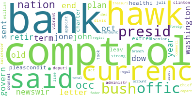

```python
# Create a WordCloud object
wordcloud = WordCloud(background_color="white",
                      max_words=500,
                      contour_width=3,
                      contour_color='steelblue')
# Generate a word cloud
long_string=(" ").join(words_processed)
wordcloud.generate(long_string)
# Visualize the word cloud
image = wordcloud.to_image()
image.show()
image.save(fig_path+'/word_cloud_example.png')
```

```python
## process all articles

all_tokens = {}  # empty dictionary to save
id_map = {} ## map the id in the dataset to the id in the matrix (some articles are empty)
to_drop_list = []

id_count = -1
for i in range(len(article_data)):
    #print(i)
    this_article = article_data['text'].iloc[i]
    if type(this_article)==str:
        #print('article '+str(i) + ' works')
        processed_docs = preprocess(this_article)
        all_tokens[i] = processed_docs
        #print(processed_docs[:10])
        id_count+=1
        id_map[i]=id_count
        #print(id_count)
    else:
        to_drop_list.append(i)
        print('not a string')

all_tokens_list = [all_tokens[i] for i in all_tokens.keys()]
```

```python
## drop articles which do not have a token list

#### This is important because it resets the index by counts
article_data = article_data.reset_index(drop=True)

print('before drop \n')
print('the length of the data set is '+str(len(article_data)))
print('the length of the token list is '+str(len(all_tokens_list)))

article_data = article_data.drop(article_data.index[to_drop_list])
## compare the article data base and the tokens to make sure every article has a token list generated


print('after drop \n')
print('the length of the data set is '+str(len(article_data)))
print('the length of the token list is '+str(len(all_tokens_list)))
```

```
before drop

the length of the data set is 2187
the length of the token list is 2187
after drop

the length of the data set is 2187
the length of the token list is 2187
```

```python
print('Here are an example of the preprocessed words from a particular article')

random_article = np.random.randint(0,100)

print(all_tokens_list[random_article])
```

```
Here are an example of the preprocessed words from a particular article
['washington', 'senat', 'major', 'leader', 'robert', 'dole', 'indic', 'prepar', 'drop', 'budget', 'demand', 'year', 'tax', 'increas', 'simpli', 'meet', 'fiscal', 'deficit', 'target', 'take', 'advantag', 'revenu', 'windfal', 'pend', 'tax', 'overhaul', 'revenu', 'tax', 'use', 'ask', 'gop', 'leader', '…
```